# STATS513 HW1

## Part A (Maximum 3 pages)

- sex: 0 = male, 1 = female
- status: socioeconomic status score based on parents’ occupation
- income: in pounds per week
- verbal: verbal score in words out of 12 correctly defined
- gamble: expenditure on gambling in pounds per year Make a numerical and graphical summary of the data, commenting on any features that you find interesting. Limit the output you present to a quantity that a busy reader would find sufficient to get a basic understanding of the data. For the variable “sex”, assign labels “male” and “female” and make sure R is treating it as a categorical variable before you compute the summary. Include your R code and graphs in the report. Also answer the following questions, incorporating the answers into your report:

```r
# load the package and the data
library("moments")
library("faraway")
data(teengamb)
```

```r
# breif view
head(teengamb)
```

A data.frame: 6 x 5

|  | sex <int> | status <int> | income <dbl> | verbal <int> | gamble <dbl> |
| --- | --- | --- | --- | --- | --- |
| 1 | 1 | 51 | 2.00 | 8 | 0.0 |
| 2 | 1 | 28 | 2.50 | 8 | 0.0 |
| 3 | 1 | 37 | 2.00 | 6 | 0.0 |
| 4 | 1 | 28 | 7.00 | 4 | 7.3 |
| 5 | 1 | 65 | 2.00 | 8 | 19.6 |
| 6 | 1 | 61 | 3.47 | 6 | 0.1 |

```r
# assign "male" and "female"
teengamb$sex <- factor(teengamb$sex)
levels(teengamb$sex) <- c("male","female")
class(teengamb$sex)
```

'factor'

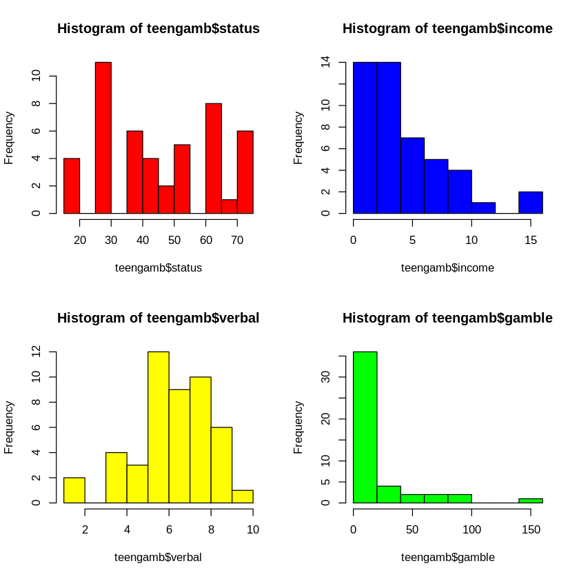

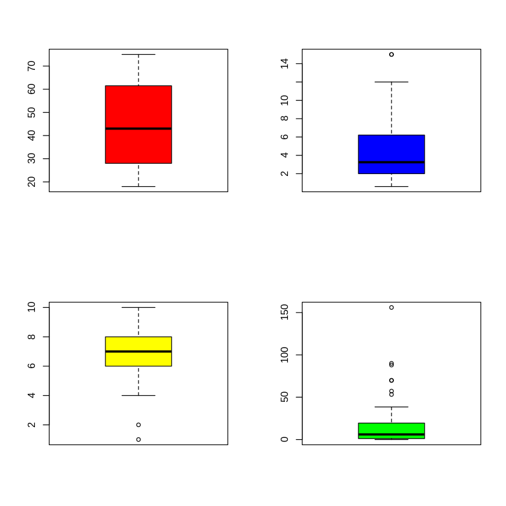

```r
par(mfrow = c(2,2), lwd = 1)
hist(teengamb$status, breaks = 10, col="Red")
hist(teengamb$income, breaks = 10, col="Blue")
hist(teengamb$verbal, breaks = 10, col="Yellow")
hist(teengamb$gamble, breaks = 10, col="Green")
boxplot(teengamb$status, col="Red")
boxplot(teengamb$income, col="Blue")
boxplot(teengamb$verbal, col="Yellow")
boxplot(teengamb$gamble, col="Green")
```

From the plots above, we find some interesting features of the dataset:

1. The teens in the dataset are randomly distributed in different social status.
2. The income of most teens are below 5 pounds a week.
3. Most of teen spend less than 20 pounds on gambling for a year.
4. There are some outliers with the boxplot corresponding to "gamble", which means there are extreme cases that some teens would spend a lot of money on gambling.

##### 1. In your summary, report the means and medians of variables “income” and “gamble”. Explain why the means are larger than the medians. (Hints: You may consider the outliers or skewness of the distribution. For skewness, please see https://en.wikipedia.org/wiki/Skewness)

```r
summary(teengamb)
```

```
     sex         status          income           verbal          gamble
 male  :28   Min.   :18.00   Min.   : 0.600   Min.   : 1.00   Min.   :  0.0
 female:19   1st Qu.:28.00   1st Qu.: 2.000   1st Qu.: 6.00   1st Qu.:  1.1
             Median :43.00   Median : 3.250   Median : 7.00   Median :  6.0
             Mean   :45.23   Mean   : 4.642   Mean   : 6.66   Mean   : 19.3
             3rd Qu.:61.50   3rd Qu.: 6.210   3rd Qu.: 8.00   3rd Qu.: 19.4
             Max.   :75.00   Max.   :15.000   Max.   :10.00   Max.   :156.0
```

We can see that there are large gaps between median and mean for the variables "income" and "gamble". The outliers and skewness are the main reasons for the means larger than the medians.

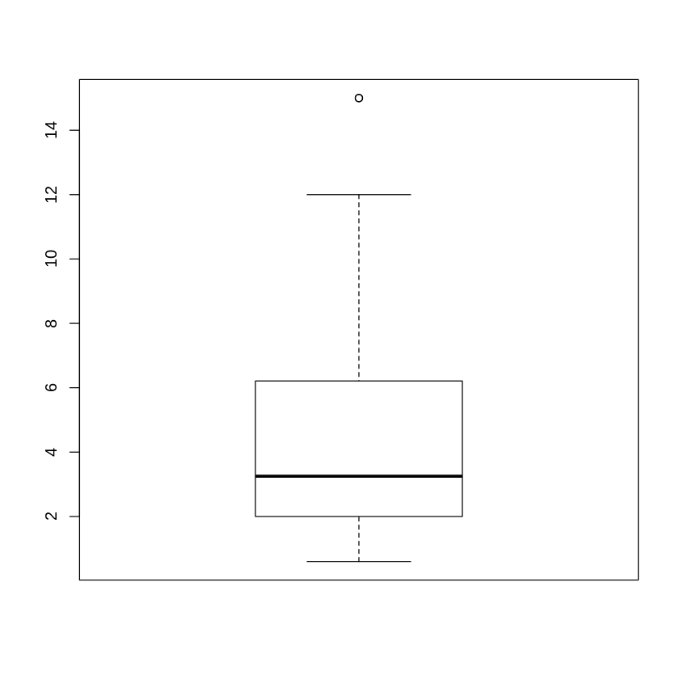

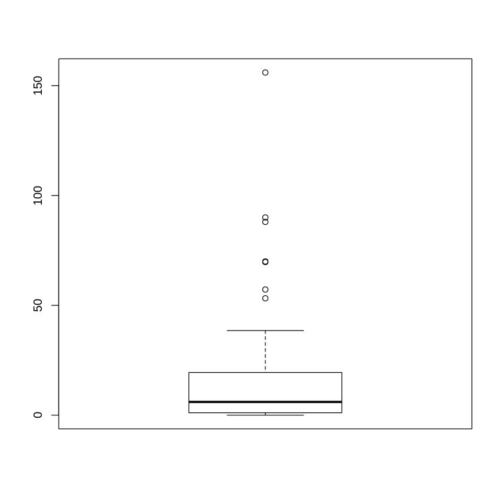

```r
# outliers
boxplot(teengamb$income)
boxplot(teengamb$gamble)
```

According to the boxpllot with "income" and "gamble", we find that there are outliers for the two variables. Even though the outlier has no relation with the median, but they will play an important role in means in other words making them larger.

```r
# skewness
skewness(teengamb$income)
skewness(teengamb$gamble)
```

1.3750560044793

2.42737060417374

The skewness of the two variables are postive, which means that the distribution of "income" and "gamble" are skewed right which means that the mean is larger than median.

##### 2. How many different values are there for the variable “verbal”? Based on the boxplot and/or other summaries of the variable “verbal”, what values of the verbal score would you consider to be outliers? Give the row numbers of the outlier observations.

```r
length(unique(teengamb$verbal))
```

9

There are 9 different values for the variable "verbal".

```
   Min. 1st Qu.  Median    Mean 3rd Qu.    Max.
   1.00    6.00    7.00    6.66    8.00   10.00
```

1. 8

2. 8

3. 6

4. 4

5. 8

6. 6

7. 7

8. 5

9. 6

10. 7

11. 6

12. 6

13. 4

14. 6

15. 6

16. 8

17. 8

18. 5

19. 8

20. 9

21. 8

22. 9

23. 5

24. 4

25. 7

26. 7

27. 4

28. 6

29. 7

30. 8

31. 2

32. 7

33. 7

34. 10

35. 1

36. 8

37. 7

38. 6

39. 6

40. 6

41. 9

42. 9

43. 8

44. 9

45. 6

46. 7

47. 9

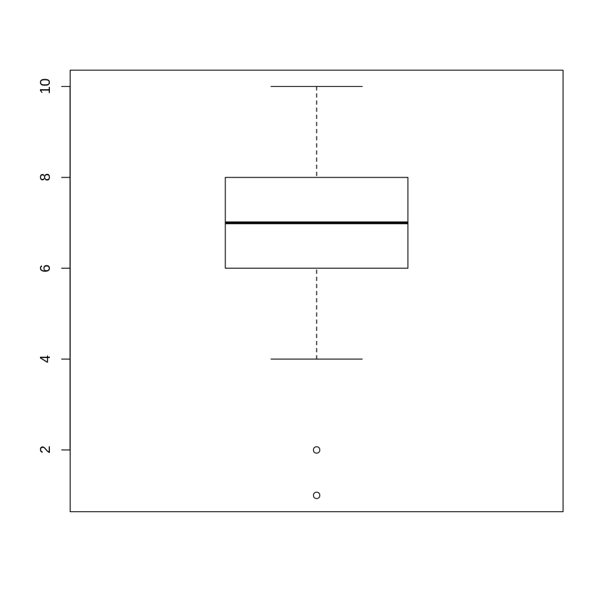

```r
summary(teengamb$verbal)
boxplot(teengamb$verbal)
teengamb$verbal
```

According to the boxplot, the range for the value is [4,10], so any number which is smaller than 4 or larger then 10 can be considered as an outlier. And there are two outliers whose indices are 31 and 35 respectively.

## Part B (Maximum 3 pages).

(1) Let $$A = \begin{bmatrix}1 \ 0\ 0 \\ 0\ 1\ 0\end{bmatrix}$$ $$B = \begin{bmatrix}0 \ 1\\0 \ 3 \\ 1 \ 2\end{bmatrix}$$

##### (b) Please show AB is singular. (Hints: You can show the columnsof AB are linear dependent or calculate the determinant to prove it)

$A B = \begin{bmatrix}1 \ 0\ 0 \\ 0\ 1\ 0\end{bmatrix} \begin{bmatrix}0 \ 1\\0 \ 3 \\ 1 \ 2\end{bmatrix} = \begin{bmatrix}0 \ 1 \\ 0 \ 3 \end{bmatrix}$

$\because A B = \begin{bmatrix}0 \ 1 \\ 0 \ 3 \end{bmatrix}\\$ $\therefore 3\times(0,1)-(0,3)=0$ Therefore, $AB$ are linear dependent

##### Bonus: Let x1 = (1, 0, 0)>, x2 = (0, 1, 0)> and x3 = (0, 0, 1)>. Please show that x1, x2 and x3 are linear independent. (Hints: Please use proof by contradiction. Firstly, assume there exists a1, a2 and a3, where at least one of a1, a2 and a3 is non-zero, such that a1x1 + a2x2 + a3x3 = (0, 0, 0)>. Secondly, show that a1x1 + a2x2 + a3x3 = (0, 0, 0)> holds only if a1 = a2 = a3 = 0.)

Given that $x_1=(1,0,0)^T, x_2 = (0,1,0)^T,x_3 = (0,0,1)^T$,\ suppose $\exist a_1,a_2,$ and $a_3$ where at least one of $a_1,a_2,$ and $a_3$ is non-zero such that $a_1x_1+a_2x_2+a_3x_3=(0,0,0)^T$. Then we have:\ $(a_1,0,0)^T+(0,a_2,0)^T+(0,0,a_3)^T=(a_1,a_2,a_3)^T=(0,0,0^T)$.\ Therefore, the equation holds if and only if $a_1=a_2=a_3=0$.\ Hence, $x_1,x_2,$ and $x_3$ are linear independent.

## Part C (Maximum 3 pages).

Fit a regression model to the teengamb dataset, with the expenditure on gambling as the response and the sex, status, income and verbal score as predictors. Present a summary output and then answer/carry out the following.

```r
# fit a regression model
regre_model <- lm(gamble ~ sex + status + income + verbal, data = teengamb)
summary(regre_model)
```

```
Call:
lm(formula = gamble ~ sex + status + income + verbal, data = teengamb)

Residuals:
    Min      1Q  Median      3Q     Max
-51.082 -11.320  -1.451   9.452  94.252

Coefficients:
             Estimate Std. Error t value Pr(>|t|)
(Intercept)  22.55565   17.19680   1.312   0.1968
sexfemale   -22.11833    8.21111  -2.694   0.0101 *
status        0.05223    0.28111   0.186   0.8535
income        4.96198    1.02539   4.839 1.79e-05 ***
verbal       -2.95949    2.17215  -1.362   0.1803
---
Signif. codes:  0 '***' 0.001 '**' 0.01 '*' 0.05 '.' 0.1 ' ' 1

Residual standard error: 22.69 on 42 degrees of freedom
Multiple R-squared:  0.5267,	Adjusted R-squared:  0.4816
F-statistic: 11.69 on 4 and 42 DF,  p-value: 1.815e-06
```

##### 1. What percentage of variation in the response is explained by these predictors? (Percentage variance explained is the same as coefficient of determination).

The percentage of variation(coefficient of determination) is multiple R-squared: 0.5267. And the adjusted R-squared id 0.4816.

##### 2. Which observation has the largest (positive) residual? Give the case number

```r
residuals(regre_model)[which.max(residuals(regre_model))]
```

**24:** 94.2522174243443

The residual with index 24 has the largest value 94.2522174243443.

##### 3. Compute the mean and median of the residuals. Explain what the difference between the mean and the median indicates.

```r
mean(residuals(regre_model))
median(residuals(regre_model))
```

4.0843510606722e-16

-1.45139206896952

The mean and the meadian of the residuals are 4.0843510606722e-16(almost 0) and -1.45139206896952, respectively.\ Since there is a gp between median and mean, we check the skewness of the distribution of residuals.

1.60407812001769

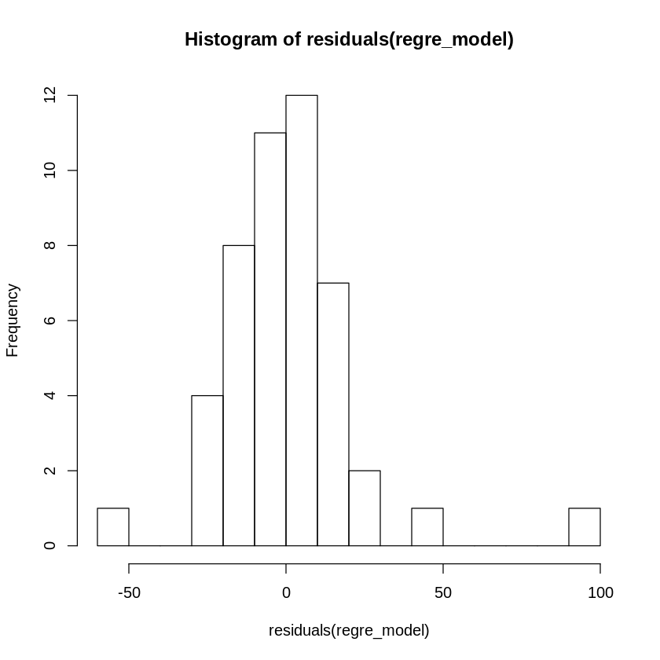

```r
skewness(residuals(regre_model))
hist(residuals(regre_model), breaks = "FD")
```

Since the skewness is postive which indicates that the distribution is right-skewd, also the plot shows the same thing.

##### 4. Compute the sample correlation between the residuals and the fit-ted values. Plot residuals against fitted values. Explain the value of this correlation using the geometric (projection) interpretation of least squares.

-1.14138128387761e-16

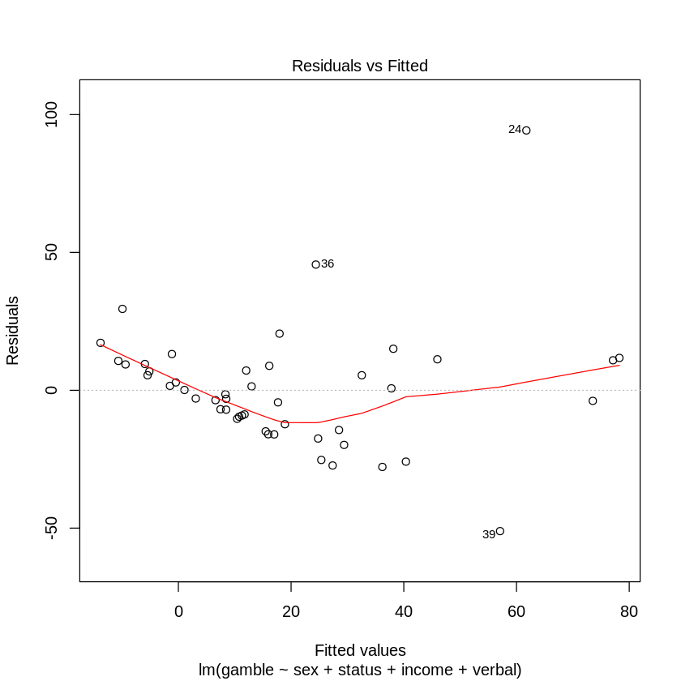

```r
cor(residuals(regre_model), fitted(regre_model))
plot(regre_model, which = 1)
```

The sample correlation between the residuals and the fitted value is -1.14138128387761e-16.\ In definition, regression will give a linear trend based on predicators and residuals are the randomness that is “leftover from a regression model” from fitting a regression model. The correlation between the explanatory variable(s) and the residuals is/are zero because there’s no linear trend left - it’s been removed by the regression.\

[figure not shown]

According to vector space interception, $min_{\beta}(y-X\beta)^T(y-X\beta)$ minimizes the Euclidean distance between $y$ and the linear space spanned by the columns of X. Here the fitted data is $X\beta$, so the residuals are perpendicular to the fitted data. Hence, the correlation between the residuals and the fitted value is almost 0.

##### 5. Compute the sample correlation between the residuals and the income.

```r
cor(residuals(regre_model),teengamb$income)
```

-8.51474764194528e-17

The sample correlation between the residuals and the income is -8.51474764194528e-17.

##### 6. For all other predictors held constant, what would be the difference in predicted expenditure on gambling for a male compared to a female?

```r
regre_model$coefficients
```

**(Intercept)**

22.5556506262134

**sexfemale**

-22.1183300928389

**status**

0.0522338438459889

**income**

4.96197921631477

**verbal**

-2.95949349938677

According to the coefficients, we kneow the coefficient of sexfemale is -22.1183300928389, therefore when other predictor held constant, female teenagers will spend 22.1183300928389 less pounds on gambling.